# Tarea 6, equipo 3

N - N

2025-12-01

Un equipo de investigadores del área de interacción humano-información está estudiando si el área temática y el nivel de dificultad del problema de información influyen en el tiempo (en segundos) que toma un usuario en formular una consulta de búsqueda para resolver dicho problema. Para ello, han reclutado a un grupo de participantes voluntarios, asignados aleatoriamente a distintos grupos. Cada participante debe resolver tres problemas de información con diferentes niveles de dificultad: baja, media y alta. A su vez, cada grupo debe resolver problemas relacionados a una temática diferente.

Equipo 3: En este momento, los investigadores buscan determinar si existen diferencias en el tiempo que tardan los usuarios en formular consultas para problemas con diferente nivel de dificultad en el área de química.

```r
data = read.csv("EP06 Datos.csv")
```

```r
#Formato largo
largeData = data %>% filter(area == "Química")
```

```r
#Reiniciamos id para poder utilizar ezANOVA
largeData <- largeData |>
  group_by(id) |>
  mutate(id = cur_group_id() - 1) |>
  ungroup() |>
  mutate(id = factor(id),dificultad = factor(dificultad))
```

```r
#Formato ancho
wideData = largeData %>% pivot_wider(names_from = dificultad, values_from = tiempo)
wideData = wideData %>% select(-area)
```

Teniendo ya los datos filtrados interesados y en formato ancho.

Para la responder la pregunta enunciada, en un contexto de medidas repetidas, se propone las siguientes hipotesis; como hipotesis nula se tiene que el tiempo promedio que tardan los usuarios en formular consultas, es el mismo para todos los niveles de dificultad en el area de quimica; como hipotesis alternativa se tiene que el tiempo promedio que tardan los usuarios en formular consultas, es diferente en al menos un nivel de dificultad en el area de quimica. Sea $t_a$ la dificultad alta, $t_m$ la dificultad media y $t_b$ la dificultad baja

$$H_0: \mu_{t_b-t_m} = \mu_{t_b-t_a} =
\mu_{t_m-t_a} = 0 \\ H_a: \exists X,Y \in \{b,m,a\},X \neq Y \mid
\mu_{t_X-t_Y} \neq 0$$

Dada las hipótesis, un test de ANOVA de una vía con muestras correlacionadas es adecuada, siempre que se tengan las condiciones necesarias para realizarla, se realizara con un grado de significancia del 0.05. La primera condición se cumple al tener como variable dependiente el tiempo, cumple con escala de intervalos iguales; la segunda condición de muestras independientes, se cumple al señalar en el enunciado que se asignaron personas aleatoreamente a los grupos, a su vez que las personas seleccionadas en el área de Química es menos del 10% población (siendo 200 personas).

Para la tercera condición, se realizaran tests de normalizacion para cada dificultad.

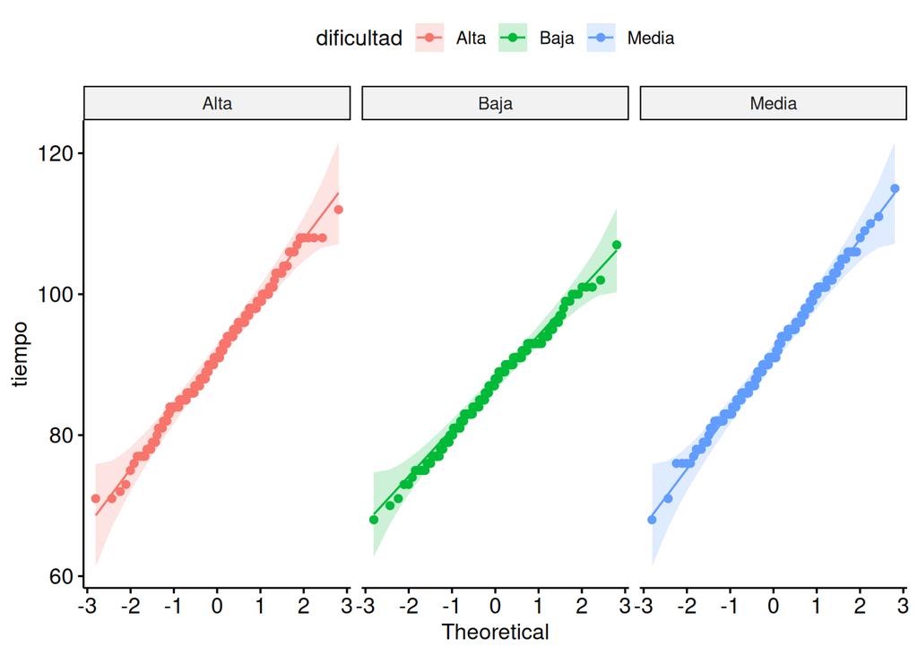

```r
largeData = largeData |> mutate(dificultad = factor(dificultad))
dataGrapNorm = ggqqplot(largeData,x="tiempo",y="tiempo",color = "dificultad", alpha = 0.1)
dataGrapNorm = dataGrapNorm + facet_wrap(~dificultad)
dataGrapNorm
```

Los gráficos presentan normalidad aunque presenta algunos outliners, por lo que veremos los test de Shapiro-Wilk para cada grupo.

```r
shapiro.test(wideData$Baja)
```

```
##
##  Shapiro-Wilk normality test
##
## data:  wideData$Baja
## W = 0.99176, p-value = 0.3177
```

```r
shapiro.test(wideData$Media)
```

```
##
##  Shapiro-Wilk normality test
##
## data:  wideData$Media
## W = 0.99593, p-value = 0.8743
```

```r
shapiro.test(wideData$Alta)
```

```
##
##  Shapiro-Wilk normality test
##
## data:  wideData$Alta
## W = 0.99337, p-value = 0.5107
```

Dados los tests de Shapiro-Wilk, las diferentes muestras fallan en rechazar la hipótesis nula de provenir de una población no parametrica con un intervalo de confianza del 95%, por lo que se cumple la tercera condición de normalidad.

La cuarta condición corresponde a que las diferencias de las varianzas de las diferentes dificultades, sean todos iguales. Afortunadamente el test ezANOVA, nos va a verificar esta condición.

```r
res = ezANOVA(data = largeData, dv = tiempo, wid = id, within = dificultad)
pruebaAov = aov(tiempo ~ dificultad + Error(id/dificultad), data=largeData)
res$`Mauchly's Test for Sphericity`
```

```
##       Effect         W         p p<.05
## 2 dificultad 0.9899065 0.3662881
```

El resultado del test de Mauchly para esfericidad, indicá el cumplimiento de esfericidad entre las muestras con un p-value de 0.366, comparado al grado de significancia 0.05, por lo que no hay que realizar un ajuste en los grados de libertad.

```r
res$ANOVA
```

```
##       Effect DFn DFd       F            p p<.05        ges
## 2 dificultad   2 398 19.6332 7.383407e-09     * 0.06488883
```

```r
summary(pruebaAov)
```

```
##
## Error: id
##            Df Sum Sq Mean Sq F value Pr(>F)
## Residuals 199  10459   52.56
##
## Error: id:dificultad
##             Df Sum Sq Mean Sq F value   Pr(>F)
## dificultad   2   2447  1223.3   19.63 7.38e-09 ***
## Residuals  398  24797    62.3
## ---
## Signif. codes:  0 '***' 0.001 '**' 0.01 '*' 0.05 '.' 0.1 ' ' 1
```

Usando los tests post-hoc de Benjamini y Hochberg.

```r
postAnova = pairwise.t.test(largeData[["tiempo"]],largeData[["dificultad"]],p.adj="fdr",paired=TRUE,conf.level = 0.95)
postAnova
```

```
##
##  Pairwise comparisons using paired t tests
##
## data:  largeData[["tiempo"]] and largeData[["dificultad"]]
##
##       Alta    Baja
## Baja  2.3e-07 -
## Media 0.67    2.1e-07
##
## P value adjustment method: fdr
```

```r
mediasEstimadas = emmeans(pruebaAov,"dificultad")
```

```
## Note: re-fitting model with sum-to-zero contrasts
```

```r
mediasEstimadas
```

```
##  dificultad emmean    SE  df lower.CL upper.CL
##  Alta         91.2 0.543 593     90.2     92.3
##  Baja         87.2 0.543 593     86.1     88.2
##  Media        91.6 0.543 593     90.5     92.7
##
## Warning: EMMs are biased unless design is perfectly balanced
## Confidence level used: 0.95
```

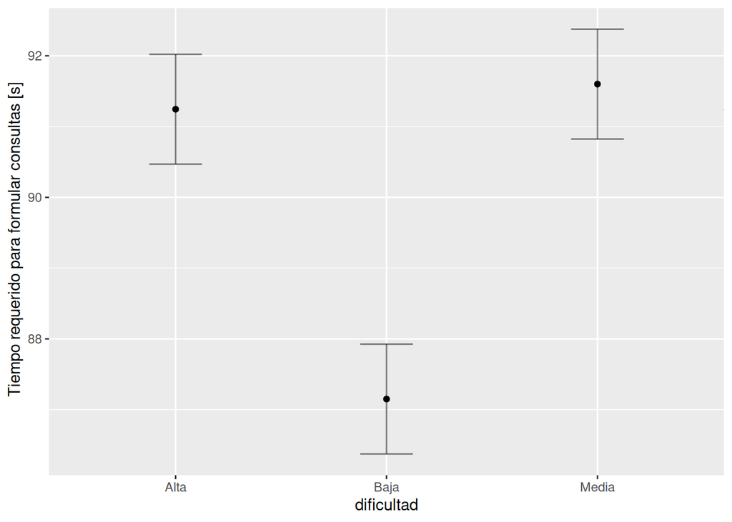

```r
consGrap = ezPlot(data = largeData, x = dificultad,
                   dv = tiempo, within = dificultad, wid = id,
                   y_lab = " Tiempo requerido para formular consultas [s]"
)
print(consGrap)
```

Dado el resultado de los tests post-hoc y el grafico, indica que el tiempo promedio requerido de una persona para formular consultas, es menor en la dificultad baja, mientras que en dificultad media y alta, el tiempo promedio requerido es mayor. De los test se rescata que el p-value de alta-media, es de 0.67, lo cual es mayor a nuestro grado de insignificancia, lo que quiere decir por t-test que no hay suficiente evidencia estadística para afirmar que sus medias son diferentes. Mientras que para alta-baja y media-baja, se tiene suficiente evidencia estadística para afirmar que los promedios son diferentes entre estos.